# Employee Satisfaction Dimension Reduction Project

Maciej Kasztelanic

Winter Semester 2023/2024 UL

## Dimension Reduction in Analysis of Employee Satisfaction based on a survey

## Data aquicition

The data set used in this aricle is a comprehensive collection of information regarding employees within a company.The dataset includes various details such as employee identification numbers, self-reported satisfaction levels, performance evaluations, project involvement, work hours, tenure with the company, work accidents, promotions received in the last 5 years, departmental affiliations, and salary levels[^1].

## Methods

In an article, two methods are used - Principal Component Analysis (PCA) and Multiple Correspondence Analysis (MCA) mixed with PCA. PCA is a widely used method for dimensionality reduction, which can help reduce the dimension of data without losing much information. It works by creating new variables, called principal components, that are linear combinations of the original variables. These components are orthogonal and capture the maximum variance in the data. MCA, on the other hand, is a method used for analyzing categorical data. It can be used to identify patterns and relationships between categorical variables. When combined with PCA, MCA can help analyze mixed data sets that contain both continuous and categorical variables. This can be particularly useful in social science research, where data sets often contain a mix of both types of variables

### Data preprocessing

Lets firstly load all needed packages

```r
library(pacman)
p_load(factoextra,psych,ClusterR,flexclust,ggthemes,dplyr,
       smacof,ggplot2,Rtsne,psy,scales,kableExtra,
       scales,corrplot,pdp,reshape2,gridExtra,FactoMineR,Hmisc,cluster)
```

Then read the data set and change it to Data Frame

```r
data <- read.csv('Employee Attrition.csv')
data<- select(data, -Emp.ID)
data <- data.frame(data)
```

Check the dimensions of the data:

```r
cat("Number of observations in the dataset:", nrow(data))
```

```
## Number of observations in the dataset: 15787
```

```r
cat("Number of years variables in the analysis:", ncol(data))
```

```
## Number of years variables in the analysis: 9
```

```r
data<-na.omit(data)
cat("Number of observations in the dataset:", nrow(data))
```

```
## Number of observations in the dataset: 14999
```

```r
cat("Number of years variables in the analysis:", ncol(data))
```

```
## Number of years variables in the analysis: 9
```

Change column name for better understanding:

```r
colnames(data)[colnames(data) == "dept"] <- "department"
```

The variables correspond to:

- satisfaction_leve: Employee’s self-reported job satisfaction level
- last_evaluation: Employee’s most recent performance evaluation score
- number_project: Number of projects the employee is currently working on
- average_monthly_hours: Average number of hours worked per month by the employee
- time_spend_company: Number of years the employee has spent with the company
- Work_accident: Indicates whether the employee has experienced a work accident (1 for yes, 0 for no)
- promotion_last_5years: Indicates whether the employee has received a promotion in the last 5 years (1 for yes, 0 for no)
- department: The department or division in which the employee works
- salary: Employee’s salary level

As in my dataset there are categorical variables I will change them into numeric

```r
print(unique(data$department))
```

```
##  [1] "sales"       "accounting"  "hr"          "technical"   "support"
##  [6] "management"  "IT"          "product_mng" "marketing"   "RandD"
```

```r
data <- data[data$department != 'RandD' & data$department != '', ]
department_mapping <- c("sales" = 0, "accounting" = 1, "hr" = 2, "technical" = 3, "support" = 4, "management" = 5, "IT" = 6, "product_mng" = 7, "marketing" = 8)
data$department <- as.numeric(factor(data$department, levels = names(department_mapping), labels = department_mapping))

print(unique(data$salary))
```

```
## [1] "low"    "medium" "high"
```

```r
salary_mapping <- c("low" = 0, "medium" = 1, "high" = 2)
data$salary <- as.numeric(factor(data$salary, levels = names(salary_mapping), labels = salary_mapping))
```

In order to better understand the data let’s plot it to check for distribution:

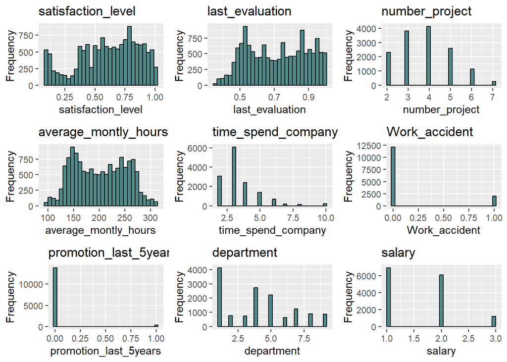

```r
gg_hist_list <- lapply(names(data), function(column_name) {
  ggplot(data, aes(x = .data[[column_name]])) +
    geom_histogram(bins = 30, fill = "darkslategray4", color = "black") +
    labs(title = column_name, x = column_name, y = "Frequency")
})
grid.arrange(grobs = gg_hist_list, ncol = 3)
```

And summarize it:

```r
summary(data)
```

```
##  satisfaction_level last_evaluation  number_project average_montly_hours
##  Min.   :0.0900     Min.   :0.3600   Min.   :2.0    Min.   : 96.0
##  1st Qu.:0.4400     1st Qu.:0.5600   1st Qu.:3.0    1st Qu.:156.0
##  Median :0.6400     Median :0.7200   Median :4.0    Median :200.0
##  Mean   :0.6124     Mean   :0.7163   Mean   :3.8    Mean   :201.1
##  3rd Qu.:0.8200     3rd Qu.:0.8700   3rd Qu.:5.0    3rd Qu.:245.0
##  Max.   :1.0000     Max.   :1.0000   Max.   :7.0    Max.   :310.0
##  time_spend_company Work_accident    promotion_last_5years   department
##  Min.   : 2.000     Min.   :0.0000   Min.   :0.00000       Min.   :1.000
##  1st Qu.: 3.000     1st Qu.:0.0000   1st Qu.:0.00000       1st Qu.:1.000
##  Median : 3.000     Median :0.0000   Median :0.00000       Median :4.000
##  Mean   : 3.505     Mean   :0.1432   Mean   :0.02055       Mean   :4.026
##  3rd Qu.: 4.000     3rd Qu.:0.0000   3rd Qu.:0.00000       3rd Qu.:6.000
##  Max.   :10.000     Max.   :1.0000   Max.   :1.00000       Max.   :9.000
##      salary
##  Min.   :1.000
##  1st Qu.:1.000
##  Median :2.000
##  Mean   :1.594
##  3rd Qu.:2.000
##  Max.   :3.000
```

## Performing PCA analysis

To understand if our data can be used to perform PCA testing I will conduct a Kaiser-Meyer-Olkin test and Bartlett’s test.

- Kaiser-Meyer-Olkin: statistical measure used to determine the sampling adequacy of data for factor analysis. It measures the proportion of variance among variables that might be common and indicates to what extent an indicator is suitable for factor analysis. The KMO criterion is calculated and returns values between 0 and 1, with values closer to 1 suggesting that the variables are correlated and the data is more suited to factor analysis. The KMO test is commonly used in social science research to evaluate the suitability of data for factor analysis.Kaiser put the following values on the results: 0.00 to 0.49 unacceptable, 0.50 to 0.59 miserable, 0.60 to 0.69 mediocre, 0.70 to 0.79 middling, 0.80 to 0.89 meritorious, and 0.90 to 1.00 marvelous[^2].
- Bartlett’s test: statistical test used to assess the equality of variance in different samples. It is used to test the null hypothesis that all k population variances are equal against the alternative that at least two are different[^3]

```r
data <- scale(data)
data_matrix<-data.matrix(data, rownames.force = NA)
dMatrix<- cor(data_matrix)

KMO(dMatrix)
```

```
## Kaiser-Meyer-Olkin factor adequacy
## Call: KMO(r = dMatrix)
## Overall MSA =  0.62
## MSA for each item =
##    satisfaction_level       last_evaluation        number_project
##                  0.39                  0.64                  0.62
##  average_montly_hours    time_spend_company         Work_accident
##                  0.66                  0.70                  0.52
## promotion_last_5years            department                salary
##                  0.51                  0.53                  0.51
```

As KMO test`s result is above 0.6 we can continue with the analysis. Altough the result is mediocre the bartlett test support futher analysis.

```r
cortest.bartlett(dMatrix, n = nrow(data))
```

```
## $chisq
## [1] 7317.024
##
## $p.value
## [1] 0
##
## $df
## [1] 36
```

To understand better relationships between variables let’s also create a correlation plot

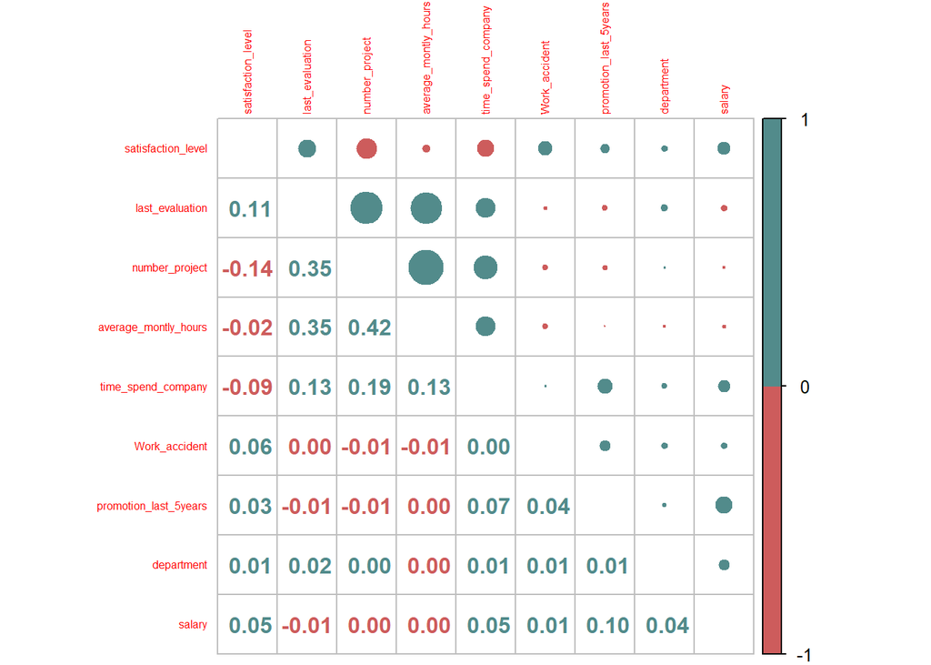

```r
corrplot.mixed(dMatrix, tl.pos = 'lt', lower.col=c("indianred", "darkslategray4"), upper.col=c("indianred", "darkslategray4"), tl.cex = 0.5)
```

We can clearly see that number of projects are positively correlated with hours spend in a month, influencing negatively the satisfaction levels.

Finally we can perform a PCA analysis:

```r
pca_data <- prcomp(data, center = TRUE, scale = TRUE)
eigen(dMatrix)$values
```

```
## [1] 1.8360022 1.1737271 1.1112420 0.9982185 0.9768658 0.8896386 0.8438553
## [8] 0.6259586 0.5444920
```

```r
summary(pca_data)
```

```
## Importance of components:
##                          PC1    PC2    PC3    PC4    PC5     PC6     PC7
## Standard deviation     1.355 1.0834 1.0542 0.9991 0.9884 0.94321 0.91862
## Proportion of Variance 0.204 0.1304 0.1235 0.1109 0.1085 0.09885 0.09376
## Cumulative Proportion  0.204 0.3344 0.4579 0.5688 0.6773 0.77619 0.86995
##                            PC8    PC9
## Standard deviation     0.79118 0.7379
## Proportion of Variance 0.06955 0.0605
## Cumulative Proportion  0.93950 1.0000
```

In order to explain 78% of variance we can reduce the number of dimensions to 6

### Number of components

The idea behind Kaiser’s Stopping Rule is that factors with eigenvalues greater than 1.0 explain more variance than a single variable and are therefore worth retaining. Factors with eigenvalues less than 1.0 are considered to be less important and can be dropped. The rule is based on the assumption that the factors are uncorrelated, which is often not the case in practice[^4].

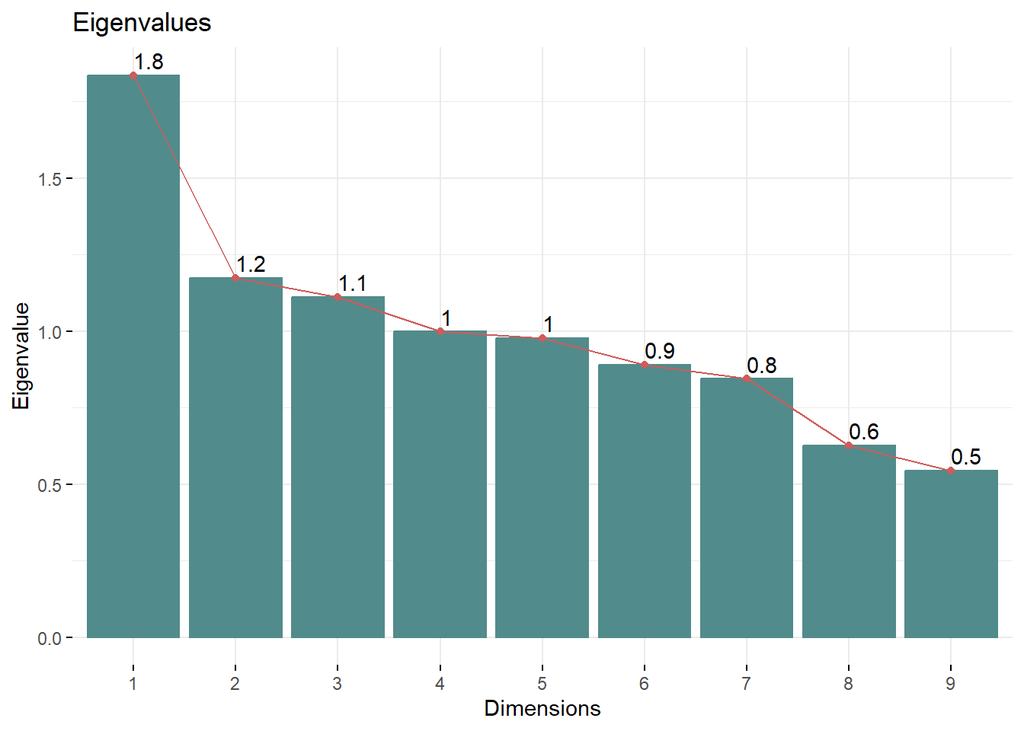

```r
fviz_eig(pca_data, choice = "eigenvalue", ncp = ncol(data), barfill = "darkslategray4", barcolor = "darkslategray4", linecolor = "indianred",  addlabels = TRUE,   main = "Eigenvalues")
```

Based on this rule we can chose 3 components, as their eigenvalues are above 1.

And then create a Scree plot explaining how much each dimension explains the variances.

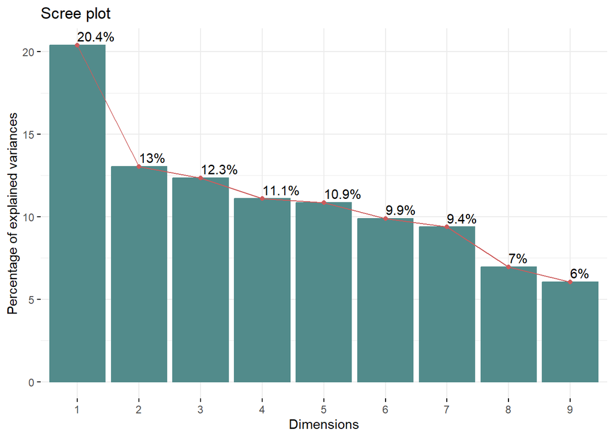

```r
fviz_screeplot(pca_data, addlabels = TRUE, barfill = "darkslategray4", barcolor = "darkslategray4", linecolor = "indianred")
```

Where for 3 diemnsions we will explain 45,7%.

To Visualize the variables better lets’s also create another variance plot

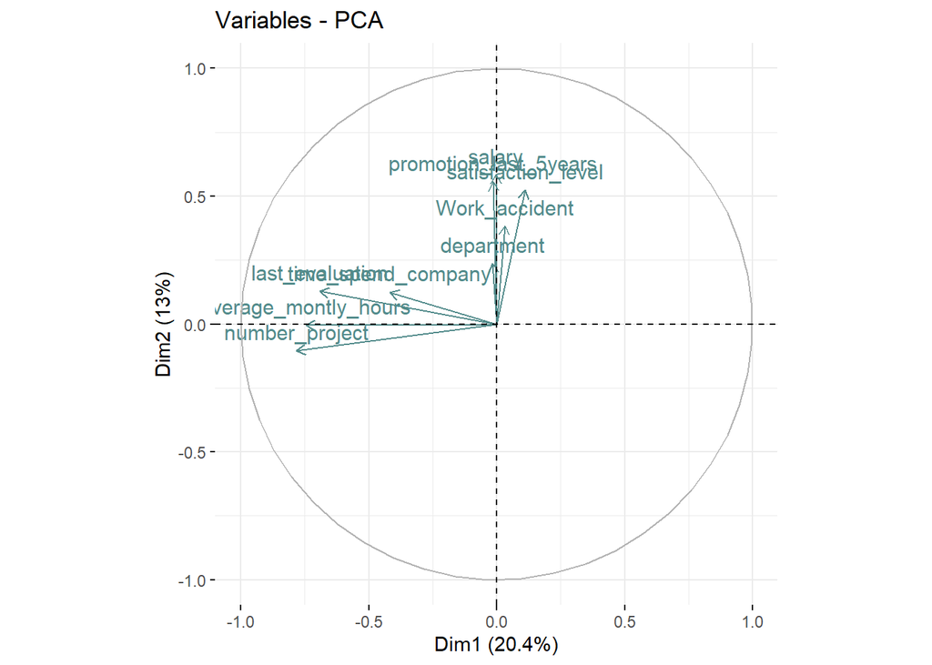

```r
fviz_pca_var(pca_data, col.var ='darkslategray4')
```

contribution of variables to dimensions refers to the extent to which each variable contributes to the variability explained by the principal components. It can be calculated as:

$$Contribution = \frac{VAR_{variable} * VAR_{principal.component}}{Total
Variance}$$

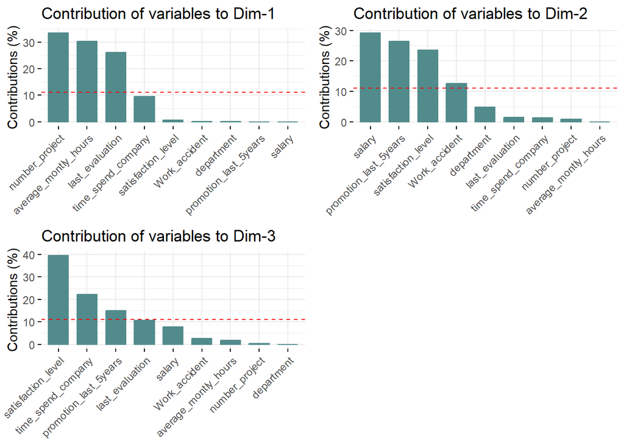

```r
pca_var <- get_pca_var(pca_data)
PC1 <- fviz_contrib(pca_data, choice = "var", axes = 1,fill = "darkslategray4",color = "darkslategray4")
PC2 <- fviz_contrib(pca_data, choice = "var", axes = 2,fill = "darkslategray4",color = "darkslategray4")
PC3 <- fviz_contrib(pca_data, choice = "var", axes = 3,fill = "darkslategray4",color = "darkslategray4")
grid.arrange(PC1, PC2, PC3, ncol=2)
```

In above graphs we can see which variables contribute the most to each principal component. All the dimension are explained by different variables.

Lastly we can perform PCA for each individual point, where for each data point we can assume the quality is being measured by its distance from the center - coordinates x=0, y=0

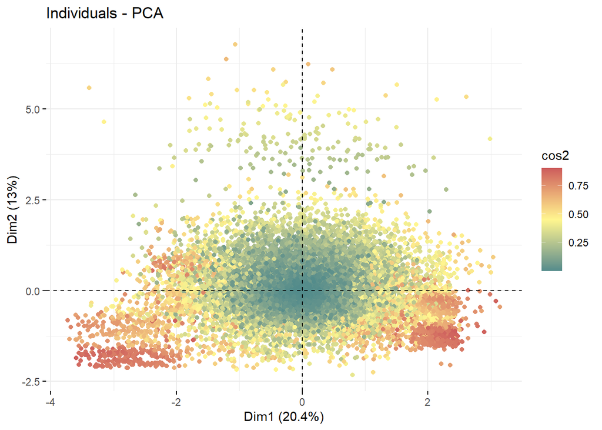

```r
fviz_pca_ind(pca_data, col.ind="cos2", geom = "point", gradient.cols = c("darkslategray4", "khaki1", "indianred" ))
```

## Perform PCA mixed with MCA

For Multiple Correspondence Analysis (MCA) mixed with Principal Component Analysis (PCA) we first need to divide variables into groups: categorical and numeric

```r
cat_data <- select(read.csv('Employee Attrition.csv'), dept, salary)
num_data <- select(read.csv('Employee Attrition.csv'), -dept, -salary, -Emp.ID)
num_data<-na.omit(num_data)
cat_data<-na.omit(cat_data)
cat_data <- cat_data[cat_data$dept != '', ]
```

```r
cat("Number of observations in the categorical dataset:", nrow(cat_data))
```

```
## Number of observations in the categorical dataset: 14999
```

```r
cat(" Number of years variables in the analysis:", ncol(cat_data))
```

```
##  Number of years variables in the analysis: 2
```

```r
cat(" Number of observations in the numeric dataset:", nrow(num_data))
```

```
##  Number of observations in the numeric dataset: 14999
```

```r
cat(" Number of years variables in the analysis:", ncol(num_data))
```

```
##  Number of years variables in the analysis: 7
```

Both data set have now same number of observations and each stores same type of variables.

Lets check wheather if the reduced numeric set qualify for the analysis:

```r
data.scale <- as.data.frame(lapply(num_data, scale))
num_data <- scale(num_data)
data_matrix_2<-data.matrix(num_data, rownames.force = NA)
dMatrix_2<- cor(data_matrix_2)
KMO(dMatrix_2)
```

```
## Kaiser-Meyer-Olkin factor adequacy
## Call: KMO(r = dMatrix_2)
## Overall MSA =  0.63
## MSA for each item =
##    satisfaction_level       last_evaluation        number_project
##                  0.40                  0.64                  0.62
##  average_montly_hours    time_spend_company         Work_accident
##                  0.66                  0.71                  0.49
## promotion_last_5years
##                  0.46
```

```r
cortest.bartlett(dMatrix_2, n = nrow(num_data))
```

```
## $chisq
## [1] 7324.147
##
## $p.value
## [1] 0
##
## $df
## [1] 21
```

And simillarly to the only PCA part, both tests are passed with KMO being mediocre.

By creating Scree plot for categorical data we will understand how the dimensions explain the variances in MCA

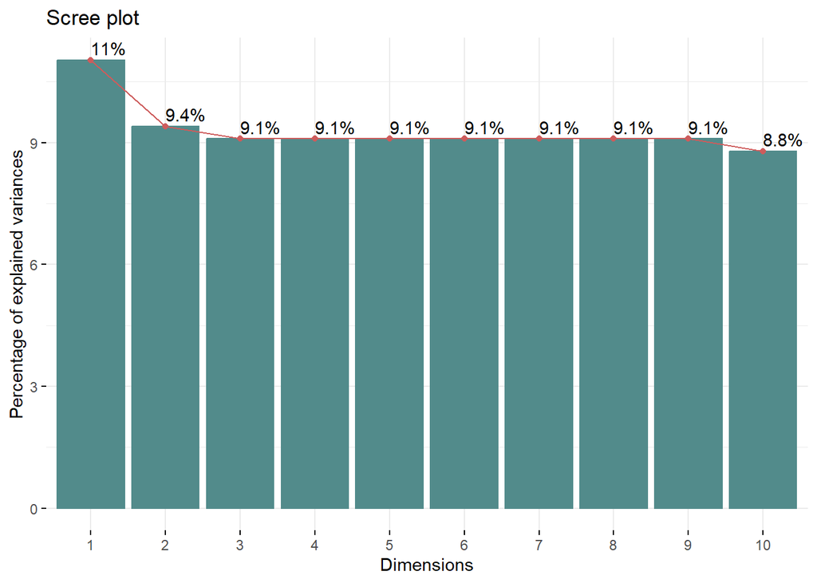

```r
mca1 <- MCA(cat_data, ncp = 2, graph = FALSE)
fviz_screeplot(mca1, addlabels = TRUE, barfill = "darkslategray4", barcolor = "darkslategray4", linecolor = "indianred")
```

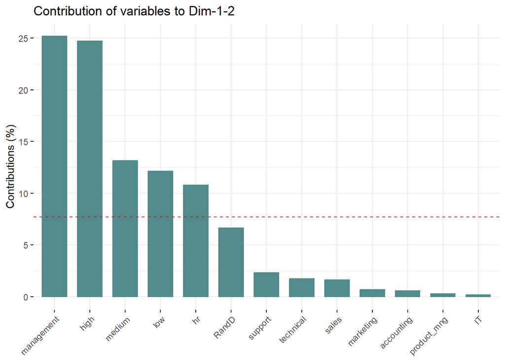

```r
fviz_contrib(mca1, choice = "var", axes = 1:2, fill = "darkslategray4", color = "darkslategray4")
```

The contribution plot for 2 dimensions shows that the combination of variables department and salary are explaining the most in this two dimensional separation

Now I can perform a PCA for the numeric variables:

```r
pca2 <- prcomp(num_data, center = TRUE, scale = TRUE)
eigen(dMatrix_2)$values
```

```
## [1] 1.8300523 1.1265210 1.0602907 0.9559227 0.8454253 0.6335936 0.5481944
```

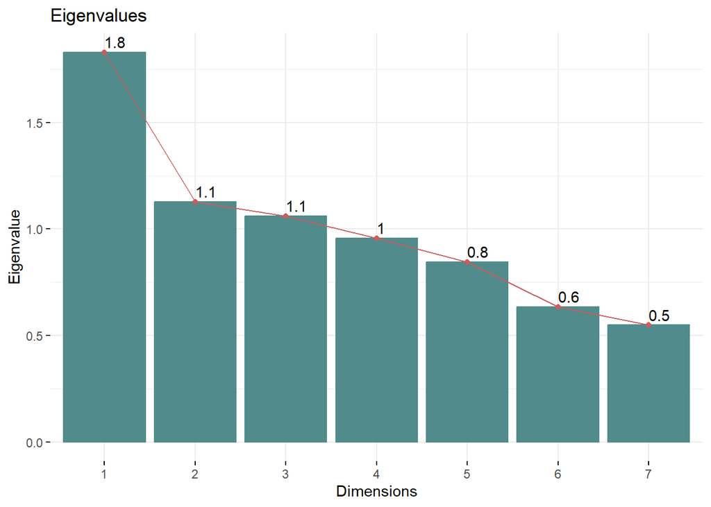

```r
fviz_eig(pca2, choice = "eigenvalue", ncp = ncol(num_data), barfill = "darkslategray4", barcolor = "darkslategray4", linecolor = "indianred",  addlabels = TRUE,   main = "Eigenvalues")
```

The Kaiser rule is again preserved where eigenvalues are higher than 1 so for 3 dimensions

By plotting the variable distribution we will be able to see contribution of each varaible.

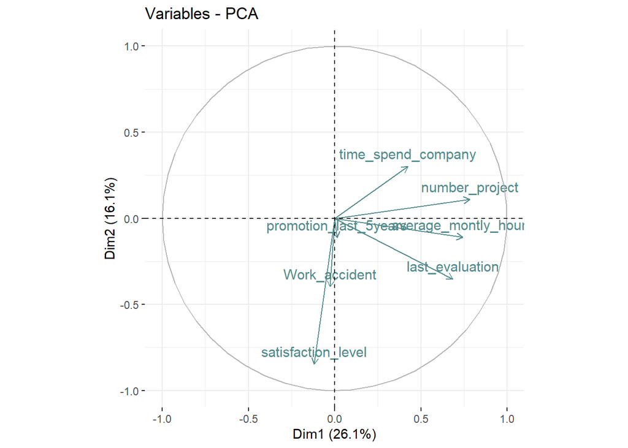

```r
fviz_pca_var(pca2, col.var = "darkslategray4")
```

And at the very end we can check the contributions of each variable to the Dimensions:

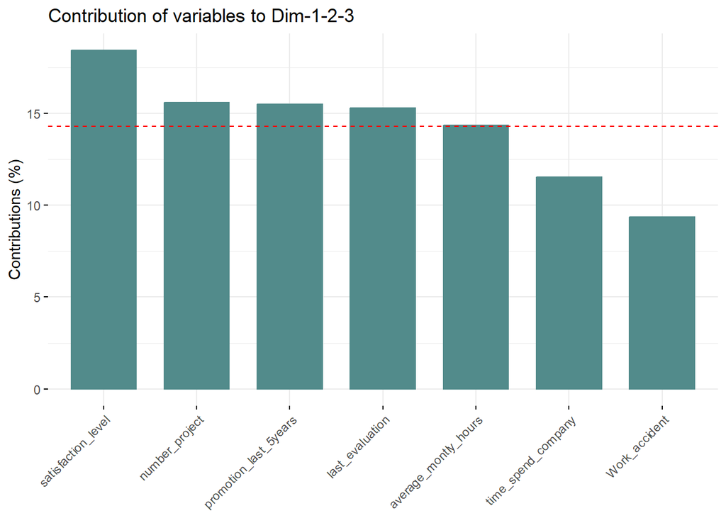

```r
fviz_contrib(pca2, choice = "var", axes = 1:3, fill = "darkslategray4", color = "darkslategray4")
```

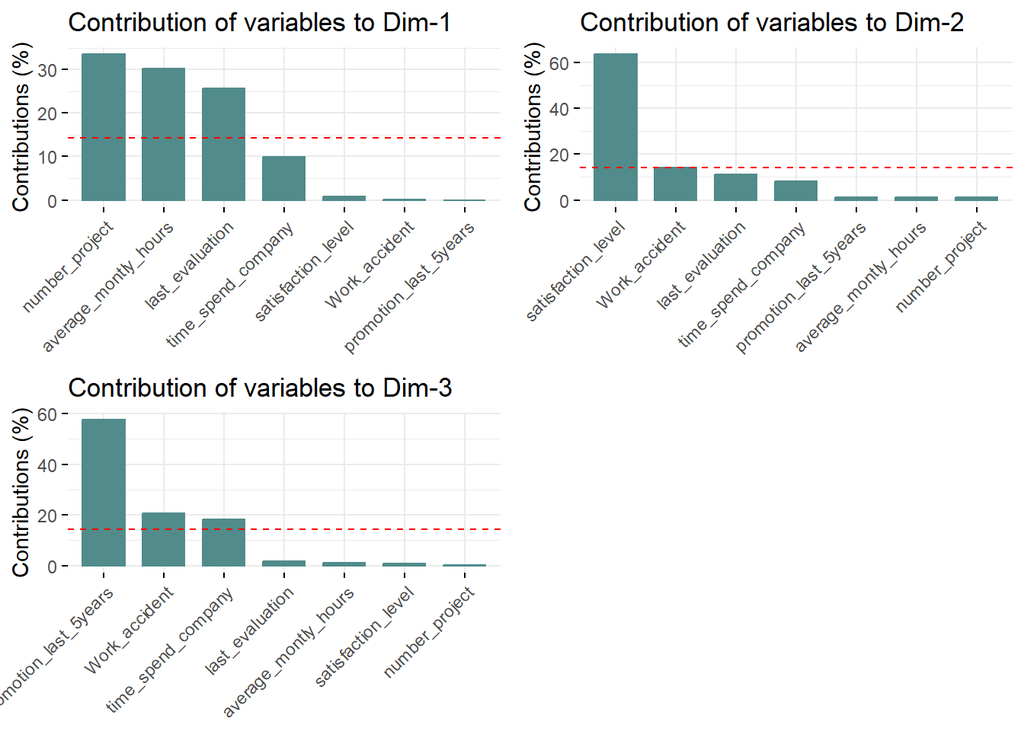

```r
pca_var <- get_pca_var(pca2)
PC4 <- fviz_contrib(pca2, choice = "var", axes = 1,fill = "darkslategray4",color = "darkslategray4")
PC5 <- fviz_contrib(pca2, choice = "var", axes = 2,fill = "darkslategray4",color = "darkslategray4")
PC6 <- fviz_contrib(pca2, choice = "var", axes = 3,fill = "darkslategray4",color = "darkslategray4")
grid.arrange(PC4, PC5, PC6, ncol=2)
```

Where the highest contributions are acheived by satisfaction_level, number_project, promotion_last_5years and last_evaluation.

Lastly we can perform hierarchical clustering on the numeric data:

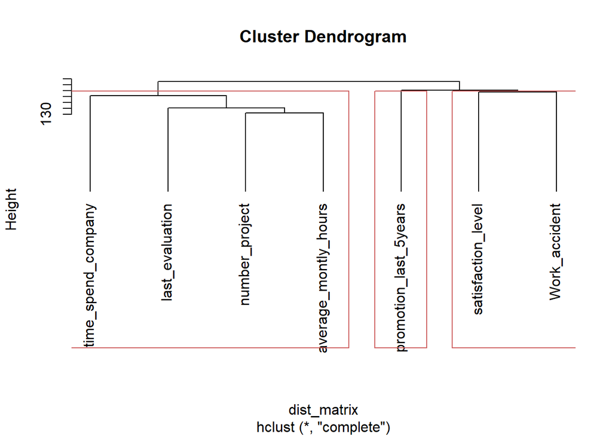

```r
transp <- t(data.scale)
dist_matrix <- dist(transp)
hc<-hclust(dist_matrix, method="complete")
plot(hc, hang = -1)
rect.hclust(hc, k = 3, border='indianred')
```

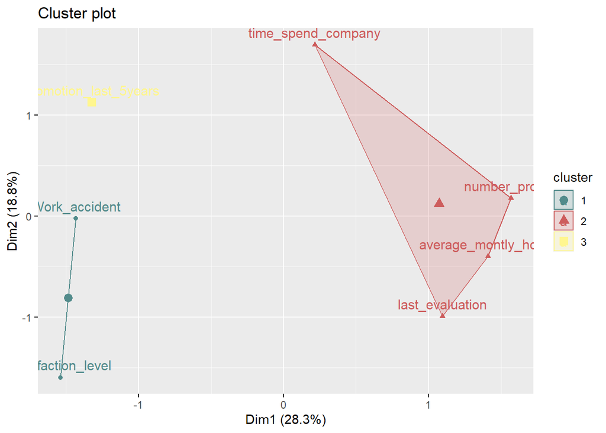

```r
sub_grp<-cutree(hc, k=3)
fviz_cluster(list(data = dist_matrix, cluster = sub_grp), palette=c("darkslategray4", "indianred", "khaki1" ))
```

With hierarchical clustering we get slightly different results, where only in dimension 1 (Dim1) all Principal components are clustered together. For rest of clusters the main components are correct, but they not all match the PCA analysis exactly. The main reason why it may be the issue is mediocracy of the data used (as shown in previous tests) so the PCA does not capture all the underlying structure of the data.

## Conculsion

[^1]: https://www.kaggle.com/datasets/redpen12/employees-satisfaction-analysis?select=Employee+Attrition.csv
[^2]: https://bookdown.org/luguben/EFA_in_R/kaiser-meyer-olkin-kmo.html
[^3]: https://en.wikipedia.org/wiki/Bartlett%27s_test
[^4]: https://hosted.jalt.org/test/bro_30.htm